# Problem Set 2

Author: Kevin Paganini  
Date: 9/13/2022  
Description: This notebook goes over numpy, matplotlib and seaborn and its use with machine learning.

### Imports

```python
import numpy as np
import matplotlib.pyplot as plt
import seaborn as sns
import pandas as pd
```

## Making a beautiful grid of points

(a), (b)

```python
x_1 = np.linspace(0, 10, 20)
x_2 = np.linspace(0, 10,20)
mesh_x1, mesh_x2 = np.meshgrid(x_1, x_2)

coords_x1 = np.reshape(mesh_x1, (400,1))
coords_x2 = np.reshape(mesh_x2, (400,1))

# Making evenly spaced data points
X = np.hstack((coords_x1, coords_x2))
print(X[0:5])
```

```
[[0.         0.        ]
 [0.52631579 0.        ]
 [1.05263158 0.        ]
 [1.57894737 0.        ]
 [2.10526316 0.        ]]
```

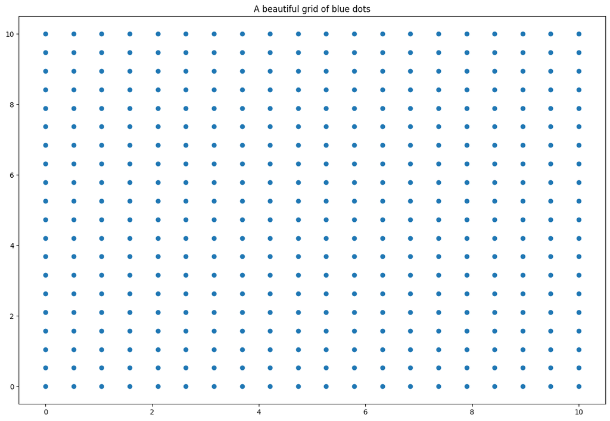

```python
fig, ax = plt.subplots(figsize=(15,10))

ax.scatter(X[:,0], X[:,1])
ax.set_title('A beautiful grid of blue dots')
```

### Making a heat map

(d)

```
[-10.          -7.36842105  -4.73684211  -2.10526316   0.52631579
   3.15789474   5.78947368   8.42105263  11.05263158  13.68421053
  16.31578947  18.94736842  21.57894737  24.21052632  26.84210526
  29.47368421  32.10526316  34.73684211  37.36842105  40.
  -8.42105263  -5.78947368  -3.15789474  -0.52631579   2.10526316
   4.73684211   7.36842105  10.          12.63157895  15.26315789
  17.89473684  20.52631579  23.15789474  25.78947368  28.42105263
  31.05263158  33.68421053  36.31578947  38.94736842  41.57894737
  -6.84210526  -4.21052632  -1.57894737   1.05263158   3.68421053
   6.31578947   8.94736842  11.57894737  14.21052632  16.84210526
  19.47368421  22.10526316  24.73684211  27.36842105  30.
  32.63157895  35.26315789  37.89473684  40.52631579  43.15789474
  -5.26315789  -2.63157895   0.           2.63157895   5.26315789
   7.89473684  10.52631579  13.15789474  15.78947368  18.42105263
  21.05263158  23.68421053  26.31578947  28.94736842  31.57894737
  34.21052632  36.84210526  39.47368421  42.10526316  44.73684211
  -3.68421053  -1.05263158   1.57894737   4.21052632   6.84210526
   9.47368421  12.10526316  14.73684211  17.36842105  20.
  22.63157895  25.26315789  27.89473684  30.52631579  33.15789474
  35.78947368  38.42105263  41.05263158  43.68421053  46.31578947
  -2.10526316   0.52631579   3.15789474   5.78947368   8.42105263
  11.05263158  13.68421053  16.31578947  18.94736842  21.57894737
  24.21052632  26.84210526  29.47368421  32.10526316  34.73684211
  37.36842105  40.          42.63157895  45.26315789  47.89473684
  -0.52631579   2.10526316   4.73684211   7.36842105  10.
  12.63157895  15.26315789  17.89473684  20.52631579  23.15789474
  25.78947368  28.42105263  31.05263158  33.68421053  36.31578947
  38.94736842  41.57894737  44.21052632  46.84210526  49.47368421
   1.05263158   3.68421053   6.31578947   8.94736842  11.57894737
  14.21052632  16.84210526  19.47368421  22.10526316  24.73684211
  27.36842105  30.          32.63157895  35.26315789  37.89473684
  40.52631579  43.15789474  45.78947368  48.42105263  51.05263158
   2.63157895   5.26315789   7.89473684  10.52631579  13.15789474
  15.78947368  18.42105263  21.05263158  23.68421053  26.31578947
  28.94736842  31.57894737  34.21052632  36.84210526  39.47368421
  42.10526316  44.73684211  47.36842105  50.          52.63157895
   4.21052632   6.84210526   9.47368421  12.10526316  14.73684211
  17.36842105  20.          22.63157895  25.26315789  27.89473684
  30.52631579  33.15789474  35.78947368  38.42105263  41.05263158
  43.68421053  46.31578947  48.94736842  51.57894737  54.21052632
```

[output cut: 25 more lines]

```
  28.42105263  31.05263158  33.68421053  36.31578947  38.94736842
  41.57894737  44.21052632  46.84210526  49.47368421  52.10526316
  54.73684211  57.36842105  60.          62.63157895  65.26315789
  16.84210526  19.47368421  22.10526316  24.73684211  27.36842105
  30.          32.63157895  35.26315789  37.89473684  40.52631579
  43.15789474  45.78947368  48.42105263  51.05263158  53.68421053
  56.31578947  58.94736842  61.57894737  64.21052632  66.84210526
  18.42105263  21.05263158  23.68421053  26.31578947  28.94736842
  31.57894737  34.21052632  36.84210526  39.47368421  42.10526316
  44.73684211  47.36842105  50.          52.63157895  55.26315789
  57.89473684  60.52631579  63.15789474  65.78947368  68.42105263
  20.          22.63157895  25.26315789  27.89473684  30.52631579
  33.15789474  35.78947368  38.42105263  41.05263158  43.68421053
  46.31578947  48.94736842  51.57894737  54.21052632  56.84210526
  59.47368421  62.10526316  64.73684211  67.36842105  70.        ]
```

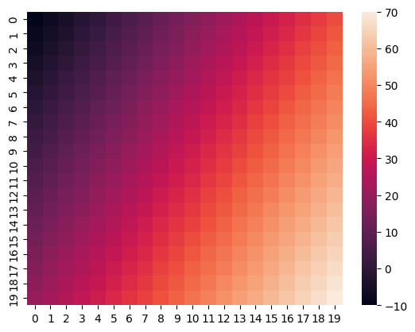

```python
w = np.array((5,3))
w_0 = -10

vectors = np.array([np.dot(foo,w) + w_0 for foo in X])

vectors_proper_shape = np.reshape(vectors,(20, 20))

print(vectors)
sns.heatmap(vectors_proper_shape)
```

## Making a binary Vector

(e)(f)

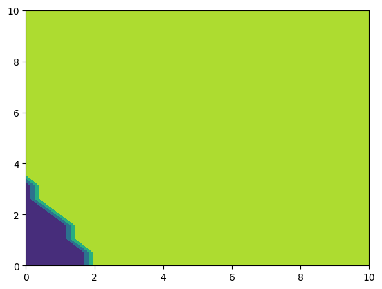

```python
y_hat = np.where(vectors > 0, 1, 0).reshape((20, 20))

plt.contourf(mesh_x1, mesh_x2, y_hat, 3)
```

### Making more categories to make plot look more colorful

```
[[0.    0.    0.    0.    0.143 0.143 0.143 0.143 0.286 0.286 0.286 0.286
  0.429 0.429 0.429 0.429 0.572 0.572 0.572 0.715]
 [0.    0.    0.    0.    0.143 0.143 0.143 0.143 0.286 0.286 0.286 0.429
  0.429 0.429 0.429 0.572 0.572 0.572 0.572 0.715]
 [0.    0.    0.    0.143 0.143 0.143 0.143 0.286 0.286 0.286 0.286 0.429
  0.429 0.429 0.429 0.572 0.572 0.572 0.715 0.715]
 [0.    0.    0.    0.143 0.143 0.143 0.286 0.286 0.286 0.286 0.429 0.429
  0.429 0.429 0.572 0.572 0.572 0.572 0.715 0.715]
 [0.    0.    0.143 0.143 0.143 0.143 0.286 0.286 0.286 0.286 0.429 0.429
  0.429 0.572 0.572 0.572 0.572 0.715 0.715 0.715]
 [0.    0.143 0.143 0.143 0.143 0.286 0.286 0.286 0.286 0.429 0.429 0.429
  0.429 0.572 0.572 0.572 0.572 0.715 0.715 0.715]
 [0.    0.143 0.143 0.143 0.286 0.286 0.286 0.286 0.429 0.429 0.429 0.429
  0.572 0.572 0.572 0.572 0.715 0.715 0.715 0.715]
 [0.143 0.143 0.143 0.143 0.286 0.286 0.286 0.286 0.429 0.429 0.429 0.572
  0.572 0.572 0.572 0.715 0.715 0.715 0.715 0.858]
 [0.143 0.143 0.143 0.286 0.286 0.286 0.286 0.429 0.429 0.429 0.429 0.572
  0.572 0.572 0.572 0.715 0.715 0.715 0.715 0.858]
 [0.143 0.143 0.143 0.286 0.286 0.286 0.429 0.429 0.429 0.429 0.572 0.572
  0.572 0.572 0.715 0.715 0.715 0.715 0.858 0.858]
 [0.143 0.143 0.286 0.286 0.286 0.286 0.429 0.429 0.429 0.429 0.572 0.572
  0.572 0.715 0.715 0.715 0.715 0.858 0.858 0.858]
 [0.143 0.143 0.286 0.286 0.286 0.429 0.429 0.429 0.429 0.572 0.572 0.572
  0.572 0.715 0.715 0.715 0.715 0.858 0.858 0.858]
 [0.143 0.286 0.286 0.286 0.286 0.429 0.429 0.429 0.572 0.572 0.572 0.572
  0.715 0.715 0.715 0.715 0.858 0.858 0.858 0.858]
 [0.286 0.286 0.286 0.286 0.429 0.429 0.429 0.429 0.572 0.572 0.572 0.572
  0.715 0.715 0.715 0.858 0.858 0.858 0.858 1.   ]
 [0.286 0.286 0.286 0.429 0.429 0.429 0.429 0.572 0.572 0.572 0.572 0.715
  0.715 0.715 0.715 0.858 0.858 0.858 0.858 1.   ]
 [0.286 0.286 0.286 0.429 0.429 0.429 0.429 0.572 0.572 0.572 0.715 0.715
  0.715 0.715 0.858 0.858 0.858 0.858 1.    1.   ]
 [0.286 0.286 0.429 0.429 0.429 0.429 0.572 0.572 0.572 0.572 0.715 0.715
  0.715 0.715 0.858 0.858 0.858 1.    1.    1.   ]
 [0.286 0.286 0.429 0.429 0.429 0.572 0.572 0.572 0.572 0.715 0.715 0.715
  0.715 0.858 0.858 0.858 0.858 1.    1.    1.   ]
 [0.286 0.429 0.429 0.429 0.429 0.572 0.572 0.572 0.572 0.715 0.715 0.715
  0.858 0.858 0.858 0.858 1.    1.    1.    1.   ]
 [0.429 0.429 0.429 0.429 0.572 0.572 0.572 0.572 0.715 0.715 0.715 0.715
  0.858 0.858 0.858 0.858 1.    1.    1.    1.   ]]
float64
```

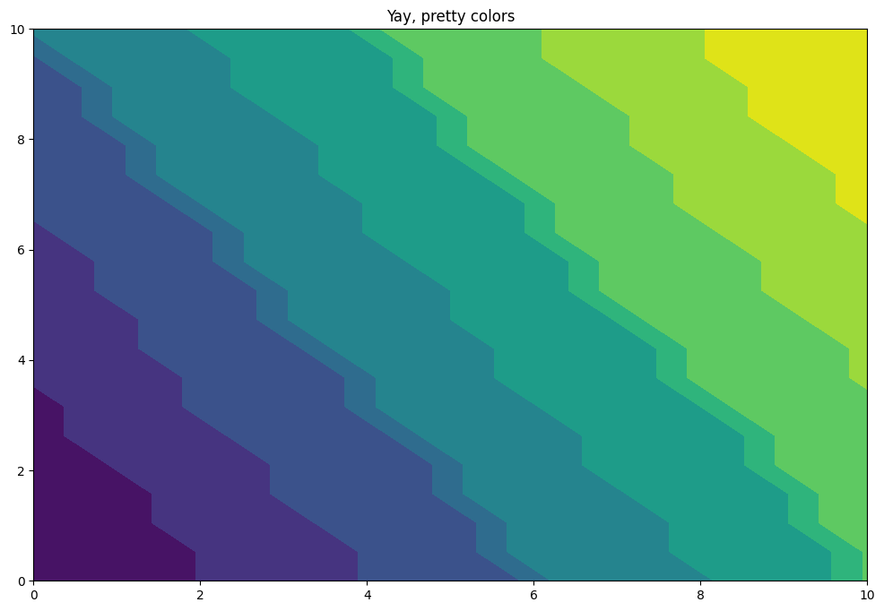

```python
def cleaner(x):
    if x <= 0:
        return 0
    elif x < 10:
        return 0.143
    elif x < 20:
        return 0.286
    elif x < 30:
        return 0.429

    elif x < 40:
        return 0.572
    elif x < 50:
        return 0.715
    elif x < 60:
        return 0.858
    elif x <= 70:
        return 1

# print(vectors)
func = np.vectorize(cleaner, otypes=[float])
y_hat_2 = func(vectors).reshape((20,20))
print(y_hat_2)
print(y_hat_2.dtype)

fig, ax = plt.subplots(figsize=(12,8))
ax.set_title('Yay, pretty colors')
ax.contourf(mesh_x1, mesh_x2, y_hat_2, 10)
```

2. In lecture, we talked about geometric objects (e.g., points, vectors, and planes) and how they

can be used to model linear decision boundaries. This problem explores some of their properties  
and how to apply these objects to classification.

(a)

(i) $$ n = (1, 1) $$ $$ r_0 = (5, 7) $$ $$ -> 1*5 + 1*7 + c = 0, $$ $$ -> c = -12 $$ $$ Plane = x + y - 12 = 0 $$

(ii) $$ n = (-1, -1) $$ $$ r_0 = (5, 7) $$ $$ -> -1*5 + -1*7 + c = 0, $$ $$ -> c = 12 $$ $$ Plane = -x - y + 12 = 0 $$

(iii)

$$ n = (1, 1, 0) $$$$ r_0 = (1, 2, 3) $$$$ -> 1*1 + 1*2 + 0*3 + c = 0, $$$$ -> c = -3 $$$$ Plane = x + y -3 = 0 $$

(iv)

$$ n = (-1, -1, 0) $$$$ r_0 = (1, 2, 3) $$$$ -> -1*1 + -1*2 + 0*3 + c = 0, $$$$ -> c = 3 $$$$ Plane = -x + -y + 3 = 0 $$

(v)

One cannot find a plane of n = (1, 3, 5, 11) and r_0 = (13, 17), because they do not have the same dimensions. The normal vector is in dim = 4 and the point in dim = 2

(vi)

The major observation to take away is that the direction of the normal vectors is simply in the opposite direction.  
What this translates to in the plane equation is that the signs are flipped. The equation of the plane is essentially the same,  
however they are mirrored across the output dimension = 0.

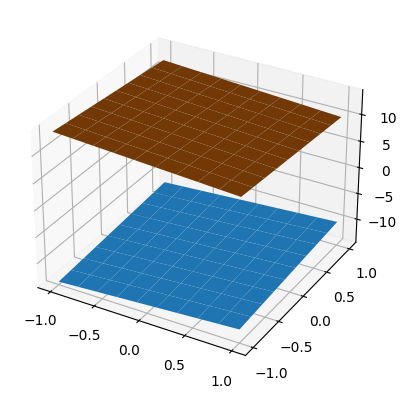

```python
import numpy as np
import matplotlib.pyplot as plt
from mpl_toolkits.mplot3d import Axes3D

x = np.linspace(-1,1,10)
y = np.linspace(-1,1,10)

X,Y = np.meshgrid(x,y)
Z_1 = X + Y - 12
Z_2 = -X -Y + 12

Z_3 = X + Y - 3
Z_4 = -X -Y + 3

fig = plt.figure()
ax = fig.gca(projection='3d')

surf = ax.plot_surface(X, Y, Z_1)
surf = ax.plot_surface(X, Y, Z_2)
ax.set_title("")
```

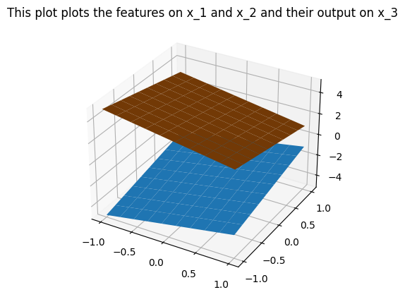

```python
fig = plt.figure()
ax = fig.gca(projection='3d')

ax.plot_surface(X, Y, Z_3)
ax.plot_surface(X, Y, Z_4)
ax.set_title("This plot plots the features on x_1 and x_2 and their output on x_3")
```

2b) Planes divide spaces in half. We can use the sign of a dot product operation to determine which side of the plane a point lies.

$$ (2, 2) * (x_1 -5, x_2 - 5) = 0 $$

That means in this case the that the normal vector is (2,2)  
The point we are plotting from is (5, 5)

So, the equation for the plane is:

$$ 2 (x_1 - 5) + 2 (x_2 - 5) = 0 $$$$ 2x_1 + 2x_2 - 20 = 0 $$$$ x_2 = 10 - x_1 $$

Finding normal vector: Subtracting points on line to create vector v $$ (2, 8) - (3,7) $$

$$ v = (-1, 1) $$

Finding vector perpendicular to vector v: $$ u * v = 0 $$

$$ -1u_1 + 1u_2 = 0 $$$$ u_1 = 1 $$$$ u_2 = 1 $$

Perpendicular vector: $$ u = (1, 1) $$

(i)

```python
x_1 = np.array([2, 3, 4, 4, 5, 6]).reshape(6, 1)
x_2 = np.array([15, 17, 13, 1, 3, 2]).reshape(6, 1)
print(x_1)
stack_x = np.hstack((x_1, x_2))
print(stack_x)

def compute_dot(x):
    return np.dot(np.array([2,2]), np.array([x[0] - 5, x[1] - 5]))

res = np.array([compute_dot(x) for x in stack_x]).reshape(6, 1)
print(res)
```

```
[[2]
 [3]
 [4]
 [4]
 [5]
 [6]]
[[ 2 15]
 [ 3 17]
 [ 4 13]
 [ 4  1]
 [ 5  3]
 [ 6  2]]
[[ 14]
 [ 20]
 [ 14]
 [-10]
 [ -4]
 [ -4]]
```

(ii)

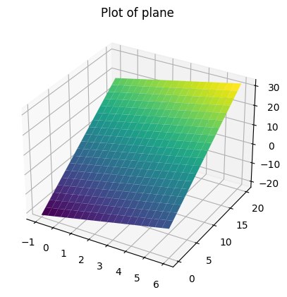

```python
fig = plt.figure()
ax = fig.gca(projection='3d')


x_mesh = np.linspace(-1, 6, 20)
y_mesh = np.linspace(0, 20, 20)

X, Y = np.meshgrid(x_mesh, y_mesh)

Z = 2*(X - 5) + 2*(Y - 5)




ax.plot_surface(X, Y, Z, cmap='viridis')


ax.set_title("Plot of plane")
# 2 (x_1 - 5) + 2 (x_2 - 5) = 0
```

To find normal equations we have to make the dot product between the point and a line equal to 0

The equation that we have for this decision boundary is:

$$ x_2 = -x_1 + 10 $$

Therefore follows,

$$ m_{model} = -1\\ m_{normal} = 1 $$

Taking the first point and plugging it in $$ x_2 = 1*x_1 + b $$

solving both to standard equation

First equation_is: $$ x_2 + x_1 = 10 $$ Second_equation_is: $$ x_2 - x_1 = b $$

```python
model_equation = np.array([1, 1])
normal_equation = np.array([-1, 1])
sys_equations = np.vstack((model_equation, normal_equation))

def find_normal_vector(x_1, x_2):
    b = x_2 - x_1
    solve_for = np.array([10, b])
    result = np.linalg.solve(sys_equations, solve_for)
    print(result)
    x = [x_1, result[0]]
    y = [x_2, result[1]]
    return x, y
```

```
[-1.5 11.5]
(2, 2)
(2, 1)
[[ 2.  -1.5]
 [15.  11.5]]
[[ 2]
 [15]]
Dot product:  [[-18.5]
 [202.5]]
[-2. 12.]
(2, 2)
(2, 1)
[[ 3. -2.]
 [17. 12.]]
[[ 3]
 [17]]
Dot product:  [[-25.]
 [255.]]
[0.5 9.5]
(2, 2)
(2, 1)
[[ 4.   0.5]
 [13.   9.5]]
[[ 4]
 [13]]
Dot product:  [[ 22.5]
 [175.5]]
[6.5 3.5]
(2, 2)
(2, 1)
[[4.  6.5]
 [1.  3.5]]
[[4]
 [1]]
Dot product:  [[22.5]
 [ 7.5]]
[6. 4.]
(2, 2)
(2, 1)
[[5. 6.]
 [3. 4.]]
[[5]
 [3]]
Dot product:  [[43.]
 [27.]]
[7. 3.]
(2, 2)
(2, 1)
[[6. 7.]
 [2. 3.]]
[[6]
 [2]]
Dot product:  [[50.]
 [18.]]
```

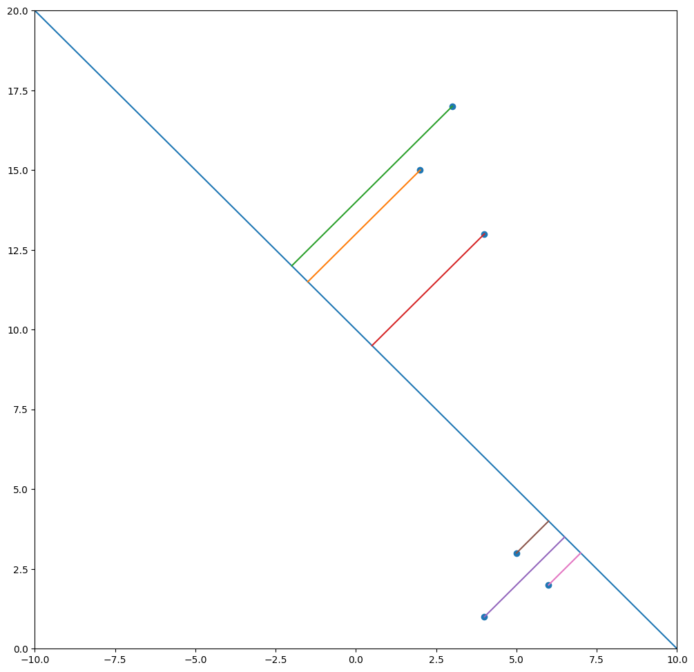

```python
fig, ax = plt.subplots(figsize=(12, 12))
plt.xlim(-10,10)
plt.ylim(0, 20)
x_mesh = np.linspace(-20, 20, 21)
ax.scatter(x_1, x_2)

y = -x_mesh + 10
ax.plot(x_mesh, y)


for point in stack_x:
    x, y = find_normal_vector(point[0], point[1])
    ax.plot(x, y)
    print(np.array([x,y]).shape)
    print(np.array(point).reshape(2,1).shape)
    print(np.array([x,y]))
    print(np.array(point).reshape(2,1))
    print('Dot product: ', np.dot(np.array([x,y]), np.array(point).reshape(2, 1)))
```

Not really sure why these aren't exactly perpendicular

## Standardization

Many machine learning algorithms are sensitive to the centering and scaling of features. Let’s walk through what this means. To “center” data, we shift the data so that the mean is 0. We do this by subtracting the mean ̄x value from every data point.

```python
df = pd.read_csv('peak_lfc-1.csv')
df.head(10)
```

|  | log_fold_change |
| --- | --- |
| 0 | 4.28351 |
| 1 | 2.79465 |
| 2 | 1.51552 |
| 3 | 1.51892 |
| 4 | 2.05290 |
| 5 | 2.44644 |
| 6 | 2.41636 |
| 7 | 2.40385 |
| 8 | 1.64442 |
| 9 | 1.96694 |

```
Mean of data: 2.4516361969377463, std: 0.7698842053022007
```

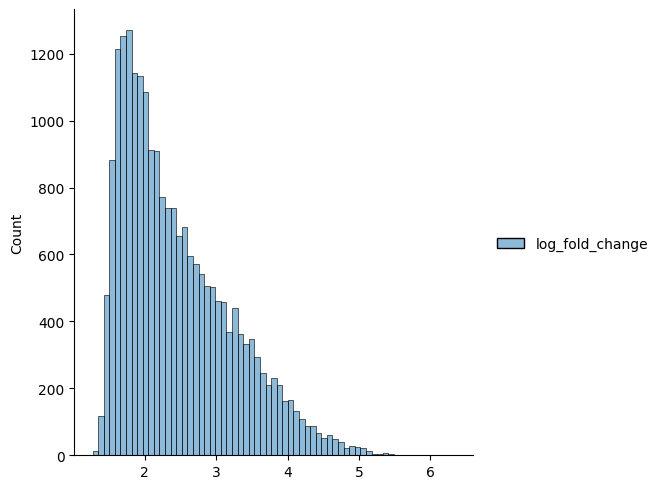

```python
sns.displot(df)
mean = np.mean(df[df.columns[0]])
std = np.std(df[df.columns[0]])
print(f'Mean of data: {mean}, std: {std}')
```

```python
data = np.array(df[df.columns[0]])

centered_data = data - mean
after_centering_mean = np.mean(centered_data)
print(f'Before centering mean:{mean}, After centering mean:{after_centering_mean}')
```

```
Before centering mean:2.4516361969377463, After centering mean:1.4283166298285685e-16
```

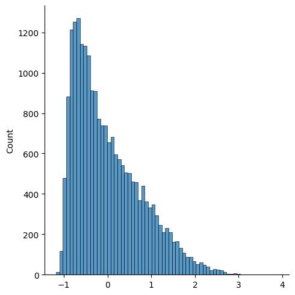

```python
sns.displot(centered_data)
```

### As one can see the data has shifted to the left and has a mean of 0.

```
Before scale: 0.7698842053022007, after scale: 1.0
```

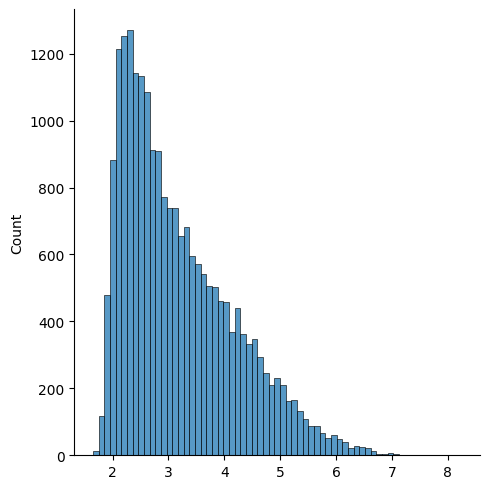

```python
std_data = data / std
sns.displot(std_data)
print(f'Before scale: {np.std(data)}, after scale: {np.std(std_data)}')
```

### As one can see the data has shifted to the right a little and covers a wider range this is so that it fulfills the std of 1

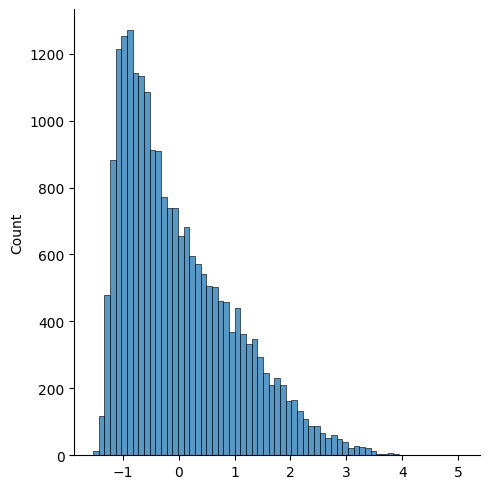

```python
# Scaling and centering
center_and_scale = centered_data / std
sns.displot(center_and_scale)
```

### The data has shifted to the left and covers a wider range

## 4 Observation distances

Explore how distance from the decision boundary is related to the output of our linear models.

```python
# model_equation = 0.75 * x - 0.9
model_x_1 = 3/4
model_x_2 = -1
normal_x_1 = -4/3
normal_x_2 = -1
model_param_array = np.array([model_x_1, model_x_2])
normal_param_array = np.array([normal_x_1, normal_x_2])
sys_equations = np.vstack((model_param_array, normal_param_array))

# This method is specifically designed for making normal vectors for the
# Iris dataset and assumes the iris decision boundary
def find_normal_vec(x_1, x_2):
    # x_2 = -4/3* x_1 + b
    b = -x_2 - 1.333*x_1

    solve_for = np.array([[0.9],[b]]) # 0.9 comes from the decision boundary equation

    result = np.linalg.solve(sys_equations, solve_for)
    x = [x_1, result[0][0]]
    y = [x_2, result[1][0]]
    return x, y



colors = ['b', 'g', 'r', 'c', 'm', 'y', 'k', '#ffa500']


def find_distance(x, y):
    p_1 = np.array([x[0], y[0]])
    p_2 = np.array([x[1], y[1]])


    dist = np.linalg.norm(p_1-p_2)

    return dist


def pick_color(dist):
    if dist < 0.125:
        return colors[0]
    elif dist < 0.25:
        return colors[1]
    elif dist < 0.375:
        return colors[2]
    elif dist < 0.5:
        return colors[3]
    elif dist < 0.625:
        return colors[4]
    elif dist < 0.75:
        return colors[5]
    elif dist < 1:
        return colors[6]
    else:
        return colors[7]
```

```
0.6478679716937166
```

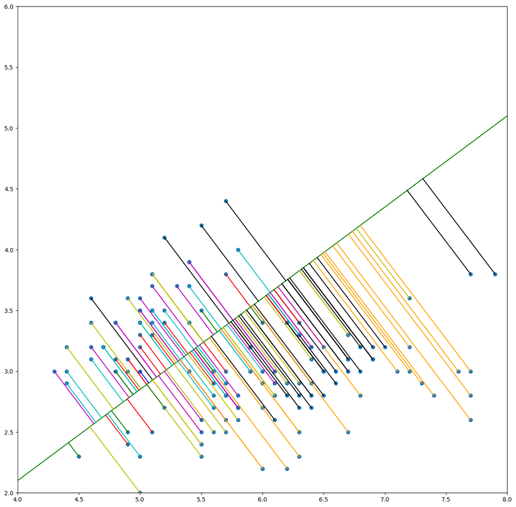

```python
from sklearn.datasets import load_iris

iris = load_iris()
iris = iris['data']
first_two_features = iris[:,0:2] # 1

x_mesh = np.linspace(4, 8)
y = 0.75 * x_mesh - 0.9

fig, ax = plt.subplots(figsize=(15, 15))
plt.xlim(4,8)
plt.ylim(2,6)
ax.scatter(first_two_features[:,0], first_two_features[:,1])
ax.plot(x_mesh, y, color='green')

# making sure my math works out
# ax.plot([5.1, 5.376], [3.5, 3.132])
# it worked out
distances = []
for x in range(first_two_features.shape[0]):
    point = first_two_features[x]
    x, y = find_normal_vec(point[0], point[1])
    # here we gotta put in the colorpicker function
    dist = find_distance(x, y)
    distances.append(dist)
    color = pick_color(dist)
    ax.plot(x, y, color=color)

print(np.mean(np.array([distances])))
```

Finding normal vector to the line

$$ y = mx + b $$

In this case m=0.75 or 3/4. The lines orthogonal slope is: $$ -1 / m $$ which is: $$ m_o = -4/3 $$

Now that we have the slope of the line perpendicular to our line equation we need to find the offset. Taking as an example the first point we can caluclate b

First point = [5.1, 3.5]

Plugging in these values into our standard line equation gives us:

$$ 3.5 = -4/3(5.1)+ b $$

which means $$ b = 10.3 $$

Now we have the equation from the model as well as the equation orthogonal to the model  
for the point 5.1, 3.5

$$ x_2 = 3/4x_1-0.9 $$$$ x_2 = -4/3x_1 +10.3 $$

Since we have two equations and two unknwons we can solve this by putting the equations into a matrix and reducing to echelon form

$$ 3/4x_1 - x_2 = 0.9 $$$$ -4/3x_1 - x_2 = -10.3 $$

In matrix form we have

$$ \begin{bmatrix} 3/4 & -1 & 0.9\\ -4/3 & -1 & -10,3 \end{bmatrix} $$

Using numpy linalg module and the solve method we can solve this equation

A = np.array([[3/4, -1], [-4/3, -1]])  
b = np.array([0.9, -10.3])  
np.linalg.solve(A,b)

giving us the answer for x_1 and x2 which in this case is [5.376, 3.132]  
The point we just calculated is the point on the line where the linear equation intersects the line

subtracting this point from the first point from the dataset we get this vector  
which we can calculate distance from:

$$ [0.276, 0.368] $$

The preceding equation is now a vector connecting our point to the line

In matplotlib to connect the point to the decision boundary we simply need to take  
the point we calculated from the row reuction formula and take the point we started with from the dataset  
and provide the x values in the x variable and the y values to the y variable

like so:

plt.plot([data[x], calc[x]], [data[y], calc[y]])

Now all we gotta do is turn all this math into python code...

```python
find_normal_vec(5.1, 3.5)
```

```
([5.1, 5.375184], [3.5, 3.1313879999999994])
```